# Practical Machine Learning - Course Project

T. Żanowska

21 stycznia 2018

## 1. Overview and background

Using devices such as Jawbone Up, Nike FuelBand, and Fitbit it is now possible to collect a large amount of data about personal activity relatively inexpensively. These type of devices are part of the quantified self movement – a group of enthusiasts who take measurements about themselves regularly to improve their health, to find patterns in their behavior, or because they are tech geeks. One thing that people regularly do is quantify how much of a particular activity they do, but they rarely quantify how well they do it.

In this project, there will be used the data from accelerometers on the belt, forearm, arm, and dumbell of 6 participant. They were asked to perform barbell lifts correctly and incorrectly in 5 different ways. The five ways are exactly according to the specification (Class A), throwing the elbows to the front (Class B), lifting the dumbbell only halfway (Class C), lowering the dumbbell only halfway (Class D) and throwing the hips to the front (Class E). Only Class A corresponds to correct performance. The goal of this project is to predict the manner in which they did the exercise.

More information is available from the website here: http://groupware.les.inf.puc-rio.br/har

## 2. Data processing

### Preparing

```r
library(knitr)
library(caret)
```

```r
library(rpart)
library(rpart.plot)
library(rattle)
library(randomForest)
library(corrplot)
library(AppliedPredictiveModeling)
```

### Import the data

Set the URL for the download

```r
UrlTrain <- "http://d396qusza40orc.cloudfront.net/predmachlearn/pml-training.csv"
UrlTest  <- "http://d396qusza40orc.cloudfront.net/predmachlearn/pml-testing.csv"
```

Download the datasets

```r
training <- read.csv(url(UrlTrain))
testing  <- read.csv(url(UrlTest))
```

Partition with the training dataset

```r
set.seed(12345)
inTrain  <- createDataPartition(training$classe, p=0.6, list=FALSE)
TrainSet <- training[inTrain, ]
TestSet  <- training[-inTrain, ]
dim(TrainSet)
```

```
## [1] 11776   160
```

```r
dim(TestSet)
```

```
## [1] 7846  160
```

### Cleaning data

Remove variables with Nearly Zero Variance

```r
NZV <- nearZeroVar(TrainSet)
TrainSet <- TrainSet[, -NZV]
TestSet  <- TestSet[, -NZV]
dim(TrainSet)
```

```
## [1] 11776   109
```

```r
dim(TestSet)
```

```
## [1] 7846  109
```

Remove variables that are mostly NA

```r
mostNA    <- sapply(TrainSet, function(x) mean(is.na(x))) > 0.95
TrainSet <- TrainSet[, mostNA==FALSE]
TestSet  <- TestSet[, mostNA==FALSE]
dim(TrainSet)
```

```
## [1] 11776    59
```

```r
dim(TestSet)
```

```
## [1] 7846   59
```

Remove columns 1 to 5 - identification variables

```r
TrainSet <- TrainSet[, -(1:5)]
TestSet  <- TestSet[, -(1:5)]
dim(TrainSet)
```

```
## [1] 11776    54
```

```r
dim(TestSet)
```

```
## [1] 7846   54
```

## 3. Prediction Algorithms

### Random Forests model

```r
set.seed(12345)
modFitRF <- randomForest(classe ~. , data=TrainSet)
predictRF <- predict(modFitRF, TestSet, type = "class")
confMatRF <- confusionMatrix(predictRF, TestSet$classe)
confMatRF
```

```
## Confusion Matrix and Statistics
##
##           Reference
## Prediction    A    B    C    D    E
##          A 2232    4    0    0    0
##          B    0 1512    3    0    0
##          C    0    2 1365   15    0
##          D    0    0    0 1270    3
##          E    0    0    0    1 1439
##
## Overall Statistics
##
##                Accuracy : 0.9964
##                  95% CI : (0.9948, 0.9976)
##     No Information Rate : 0.2845
##     P-Value [Acc > NIR] : < 2.2e-16
##
##                   Kappa : 0.9955
##  Mcnemar's Test P-Value : NA
##
## Statistics by Class:
##
##                      Class: A Class: B Class: C Class: D Class: E
## Sensitivity            1.0000   0.9960   0.9978   0.9876   0.9979
## Specificity            0.9993   0.9995   0.9974   0.9995   0.9998
## Pos Pred Value         0.9982   0.9980   0.9877   0.9976   0.9993
## Neg Pred Value         1.0000   0.9991   0.9995   0.9976   0.9995
## Prevalence             0.2845   0.1935   0.1744   0.1639   0.1838
## Detection Rate         0.2845   0.1927   0.1740   0.1619   0.1834
## Detection Prevalence   0.2850   0.1931   0.1761   0.1622   0.1835
## Balanced Accuracy      0.9996   0.9978   0.9976   0.9936   0.9989
```

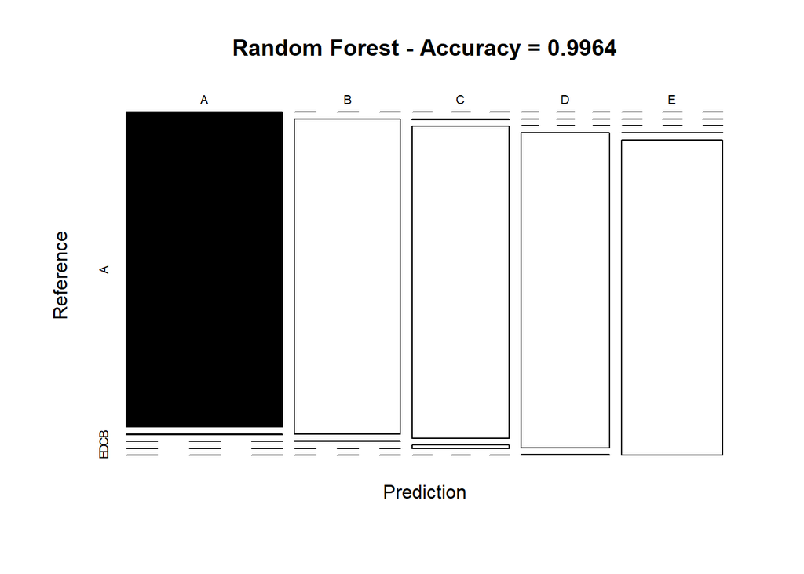

```r
# plot matrix results
plot(confMatRF$table, col = confMatRF$byClass,
     main = paste("Random Forest - Accuracy =",
                  round(confMatRF$overall['Accuracy'], 4)))
```

### Decision Trees model

```r
set.seed(12345)
modFitDT <- rpart(classe ~ ., data=TrainSet, method="class")
predictDT <- predict(modFitDT, TestSet, type = "class")
confMatDT<-confusionMatrix(predictDT, TestSet$classe)
confMatDT# plot matrix results
```

```
## Confusion Matrix and Statistics
##
##           Reference
## Prediction    A    B    C    D    E
##          A 1961  121    1   33    8
##          B   57 1067   43   41  130
##          C   54  152 1098   63   21
##          D  152  160  193 1061  226
##          E    8   18   33   88 1057
##
## Overall Statistics
##
##                Accuracy : 0.7958
##                  95% CI : (0.7867, 0.8047)
##     No Information Rate : 0.2845
##     P-Value [Acc > NIR] : < 2.2e-16
##
##                   Kappa : 0.7427
##  Mcnemar's Test P-Value : < 2.2e-16
##
## Statistics by Class:
##
##                      Class: A Class: B Class: C Class: D Class: E
## Sensitivity            0.8786   0.7029   0.8026   0.8250   0.7330
## Specificity            0.9710   0.9572   0.9552   0.8886   0.9770
## Pos Pred Value         0.9233   0.7975   0.7911   0.5921   0.8779
## Neg Pred Value         0.9526   0.9307   0.9582   0.9628   0.9420
## Prevalence             0.2845   0.1935   0.1744   0.1639   0.1838
## Detection Rate         0.2499   0.1360   0.1399   0.1352   0.1347
## Detection Prevalence   0.2707   0.1705   0.1769   0.2284   0.1535
## Balanced Accuracy      0.9248   0.8300   0.8789   0.8568   0.8550
```

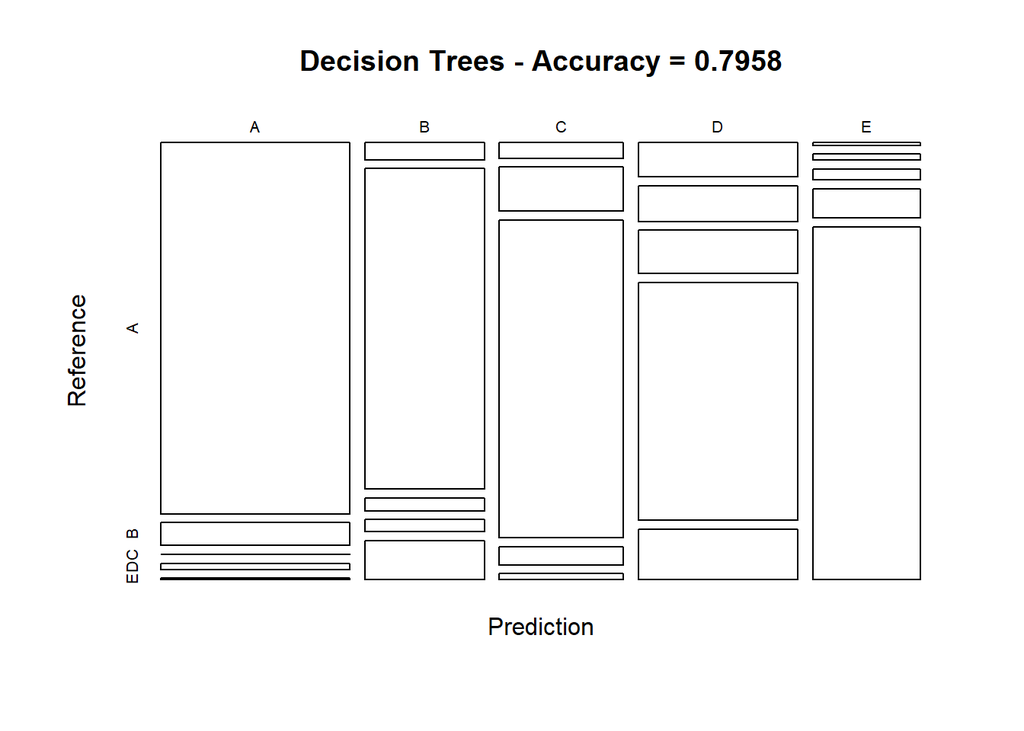

```r
plot(confMatDT$table, col = confMatDT$byClass,
     main = paste("Decision Trees - Accuracy =",
                  round(confMatDT$overall['Accuracy'], 4)))
```

For this dataset, Random Forests method is better than Decission Trees.

Decission Trees - the accuracy rate is 0.7958, and so the out-of-sample error rate is 0.2042

Therefore, Random Forests method was chosen to predict classes for the test samples.

## 4. Predicting for the Test Samples

The Random Forests model wil be used to predict the outcome variable classe for the testing set.

```r
finalPredictions<-predict(modFitRF,newdata=testing)
finalPredictions
```

```
##  1  2  3  4  5  6  7  8  9 10 11 12 13 14 15 16 17 18 19 20
##  B  A  B  A  A  E  D  B  A  A  B  C  B  A  E  E  A  B  B  B
## Levels: A B C D E
```